# Who Survived the Titanic?

### `SibSp`

Number of siblings or spouses of the passenger on the Titanic. This is a numerical variable.

```python
df[["SibSp", "Survived"]].groupby(['SibSp'], as_index=False).mean()
```

|  | SibSp | Survived |
| --- | --- | --- |
| 0 | 0 | 0.345395 |
| 1 | 1 | 0.535885 |
| 2 | 2 | 0.464286 |
| 3 | 3 | 0.250000 |
| 4 | 4 | 0.166667 |
| 5 | 5 | 0.000000 |
| 6 | 8 | 0.000000 |

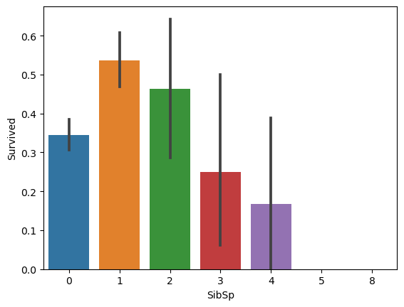

```python
sns.barplot(x="SibSp", y="Survived", data=df)
```

### `Parch`

Parents and children of the passenger inside the Titanic. It is a numerical variable.

```python
df[["Parch", "Survived"]].groupby(['Parch'], as_index=False).mean()
```

|  | Parch | Survived |
| --- | --- | --- |
| 0 | 0 | 0.343658 |
| 1 | 1 | 0.550847 |
| 2 | 2 | 0.500000 |
| 3 | 3 | 0.600000 |
| 4 | 4 | 0.000000 |
| 5 | 5 | 0.200000 |
| 6 | 6 | 0.000000 |

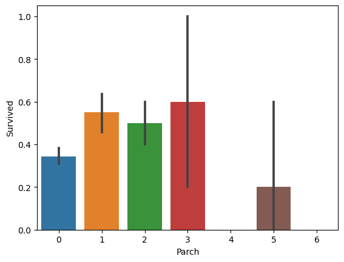

```python
sns.barplot(x="Parch", y="Survived", data=df)
```

### `FamilySize`

With the variables `SibSp` and `Parch` we can calculate the size of a passenger's family + 1 member, which we will call `FamilySize`. It will therefore be a numeric variable.

```python
df['FamilySize'] = df['SibSp'] + df['Parch'] + 1
df[["FamilySize", "Survived"]].groupby(['FamilySize'], as_index=False).mean()
```

|  | FamilySize | Survived |
| --- | --- | --- |
| 0 | 1 | 0.303538 |
| 1 | 2 | 0.552795 |
| 2 | 3 | 0.578431 |
| 3 | 4 | 0.724138 |
| 4 | 5 | 0.200000 |
| 5 | 6 | 0.136364 |
| 6 | 7 | 0.333333 |
| 7 | 8 | 0.000000 |
| 8 | 11 | 0.000000 |

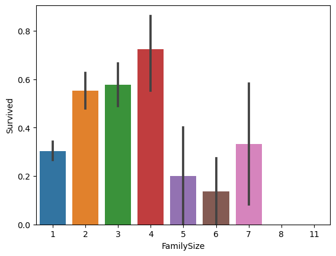

```python
sns.barplot(x="FamilySize", y="Survived", data=df)
```

### `IsAlone`

It is interesting to characterise whether the passenger has no family inside the Titanic. Assuming that the one-member families on the titanic are in fact one person alone. We will calculate the binary variable `IsAlone`.

```python
df['IsAlone'] = 0
df.loc[df['FamilySize'] == 1, 'IsAlone'] = 1
df[['IsAlone', 'Survived']].groupby(['IsAlone'], as_index=False).mean()
```

|  | IsAlone | Survived |
| --- | --- | --- |
| 0 | 0 | 0.505650 |
| 1 | 1 | 0.303538 |

```python
print(df)
```

```
     Survived  Pclass                                               Name  \
0           0       3                            Braund, Mr. Owen Harris
1           1       1  Cumings, Mrs. John Bradley (Florence Briggs Th...
2           1       3                             Heikkinen, Miss. Laina
3           1       1       Futrelle, Mrs. Jacques Heath (Lily May Peel)
4           0       3                           Allen, Mr. William Henry
..        ...     ...                                                ...
886         0       2                              Montvila, Rev. Juozas
887         1       1                       Graham, Miss. Margaret Edith
888         0       3           Johnston, Miss. Catherine Helen "Carrie"
889         1       1                              Behr, Mr. Karl Howell
890         0       3                                Dooley, Mr. Patrick

       Sex   Age  SibSp  Parch            Ticket     Fare Cabin Embarked  \
0     True  22.0      1      0         A/5 21171   7.2500   NaN        S
```

[output cut: 25 more lines]

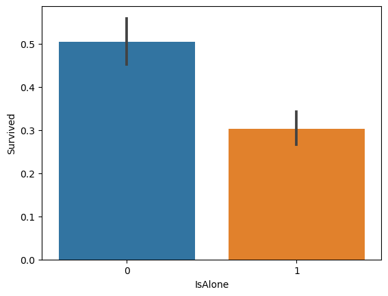

```python
sns.barplot(x="IsAlone", y="Survived", data=df)
```

### `Ticket`

Passenger ticket number. It is alphanumeric and a priori does not offer information that could help us in the predictive model. We will not include it.

```python
df.drop(['Ticket'], axis=1, inplace=True)
```

### `Embarked`

Indicates the passenger's port of embarkation. It is a categorical variable where `C` indicates embarkation at Cherbourg, `Q` at Queenstown and `S` at Southampton. We will complete the infinite values by imputing the port of departure as Southampton.

```python
df['Embarked'] = df['Embarked'].fillna('S')
df[['Embarked', 'Survived']].groupby(['Embarked'], as_index=False).mean()
```

|  | Embarked | Survived |
| --- | --- | --- |
| 0 | C | 0.553571 |
| 1 | Q | 0.389610 |
| 2 | S | 0.339009 |

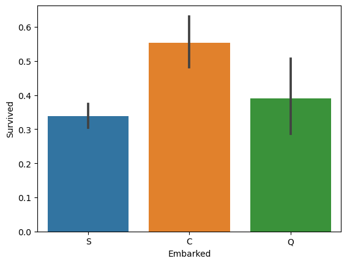

```python
sns.barplot(x="Embarked", y="Survived", data=df)
```

### `Fare`

It indicates the price of the ticket. It is therefore a continuous numerical variable.

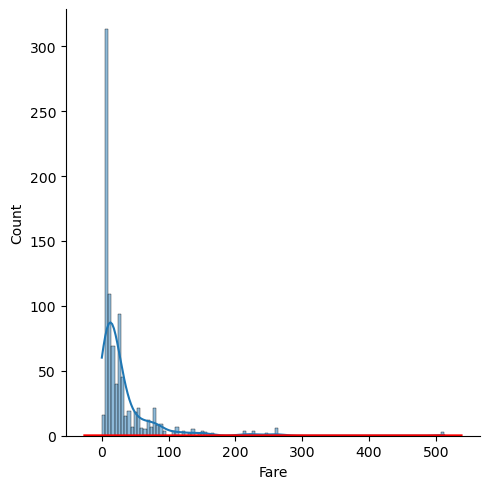

```python
from scipy.stats import norm

# Ploting the distribution of 'Fare'
sns.displot(df['Fare'], kde=True)

# Fiting a normal distribution to the data
mu, std = norm.fit(df['Fare'])
xmin, xmax = plt.xlim()
x = np.linspace(xmin, xmax, 100)
p = norm.pdf(x, mu, std)
plt.plot(x, p, 'r', linewidth=2)

# Show the plot
plt.show()
```

We transform the variable into a categorical variable.In other words, we are going to discretise them

```python
df['FareGroup'] = pd.qcut(df['Fare'], 7, labels=['A', 'B', 'C', 'D', 'E', 'F', 'G'])
df[['FareGroup', 'Survived']].groupby(['FareGroup'], as_index=False).mean()
```

|  | FareGroup | Survived |
| --- | --- | --- |
| 0 | A | 0.207143 |
| 1 | B | 0.200000 |
| 2 | C | 0.316327 |
| 3 | D | 0.406250 |
| 4 | E | 0.445312 |
| 5 | F | 0.456000 |
| 6 | G | 0.685039 |

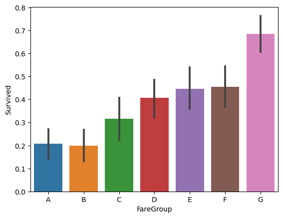

```python
sns.barplot(x="FareGroup", y="Survived", data=df)
```

We eliminate the variable we do not need

```python
df.drop(['Fare'], axis=1, inplace=True)
```

## `Cabin`

Passenger cabin number. This is a text variable, indicating which cabin the passenger was in. We will transform the variable into a binary variable depending on whether the passenger was in a cabin or not.

```python
df['InCabin'] = ~df['Cabin'].isnull()
```

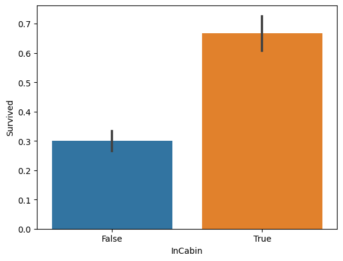

```python
sns.barplot(x="InCabin", y="Survived", data=df)
plt.show()
```

```python
df.drop(['Cabin'], axis=1, inplace=True)
```

### `Age`

Edad del pasajero. Es una variable numerica que tiene bastantes valores vacios. Categorizaremos la variable en 8 categorías según la edad que tenga. La categoría `Unknown` será la de aquellos pasajeros que no tengamos la edad.

```python
df["Age"] = df["Age"].fillna(-0.5)
bins = [-1, 0, 5, 12, 18, 24, 35, 60, np.inf]
labels = ['Unknown', 'Baby', 'Child', 'Teenager', 'Student', 'Young Adult', 'Adult', 'Senior']
df['AgeGroup'] = pd.cut(df["Age"], bins, labels = labels)
```

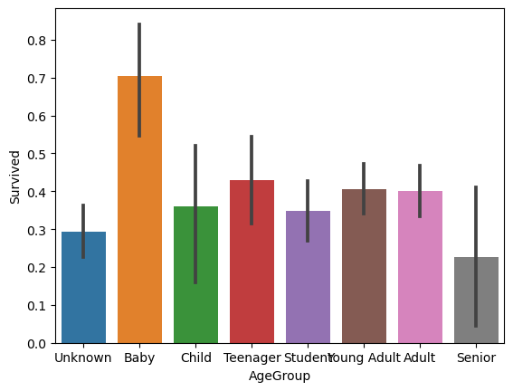

```python
sns.barplot(x="AgeGroup", y="Survived", data=df)
plt.show()
```

```python
df.drop(['Age'], axis=1, inplace=True)
```

### `Name`.

Name of the passenger. From this variable we can extract the titles included with the name, such as `Mr`, `Miss` or `Master`, which can have a predictive value. The rest of the name, we will ignore.

```python
df['Name'].head(10)
```

```
0                              Braund, Mr. Owen Harris
1    Cumings, Mrs. John Bradley (Florence Briggs Th...
2                               Heikkinen, Miss. Laina
3         Futrelle, Mrs. Jacques Heath (Lily May Peel)
4                             Allen, Mr. William Henry
5                                     Moran, Mr. James
6                              McCarthy, Mr. Timothy J
7                       Palsson, Master. Gosta Leonard
8    Johnson, Mrs. Oscar W (Elisabeth Vilhelmina Berg)
9                  Nasser, Mrs. Nicholas (Adele Achem)
Name: Name, dtype: object
```

```python
def get_title(name):
    title_search = re.search(' ([A-Za-z]+)\.', name)
    if title_search:
        return title_search.group(1)
    return ""

df['Title'] = df['Name'].apply(get_title)

pd.crosstab(df['Title'], df['Sex'])
```

| Sex Title | False | True |
| --- | --- | --- |
| Capt | 0 | 1 |
| Col | 0 | 2 |
| Countess | 1 | 0 |
| Don | 0 | 1 |
| Dr | 1 | 6 |
| Jonkheer | 0 | 1 |
| Lady | 1 | 0 |
| Major | 0 | 2 |
| Master | 0 | 40 |
| Miss | 182 | 0 |
| Mlle | 2 | 0 |
| Mme | 1 | 0 |
| Mr | 0 | 517 |
| Mrs | 125 | 0 |
| Ms | 1 | 0 |
| Rev | 0 | 6 |
| Sir | 0 | 1 |

Categorizaremos aquellos títulos que sean mas usados, y el resto los agruparemos a una categoría `Rare`.

```python
df['Title'] = df['Title'].replace(['Lady', 'Countess','Capt', 'Col', 'Don', 'Dr', 'Major', 'Rev', 'Sir', 'Jonkheer', 'Dona'], 'Rare')
df['Title'] = df['Title'].replace('Mlle', 'Miss')
df['Title'] = df['Title'].replace('Ms', 'Miss')
df['Title'] = df['Title'].replace('Mme', 'Mrs')

df[['Title', 'Survived']].groupby(['Title'], as_index=False).mean()
```

|  | Title | Survived |
| --- | --- | --- |
| 0 | Master | 0.575000 |
| 1 | Miss | 0.702703 |
| 2 | Mr | 0.156673 |
| 3 | Mrs | 0.793651 |
| 4 | Rare | 0.347826 |

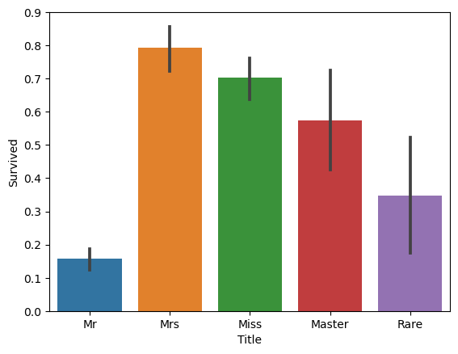

```python
sns.barplot(x="Title", y="Survived", data=df)
plt.show()
```

```python
df.drop(['Name'], axis=1, inplace=True)
```

## Correlation of the variables

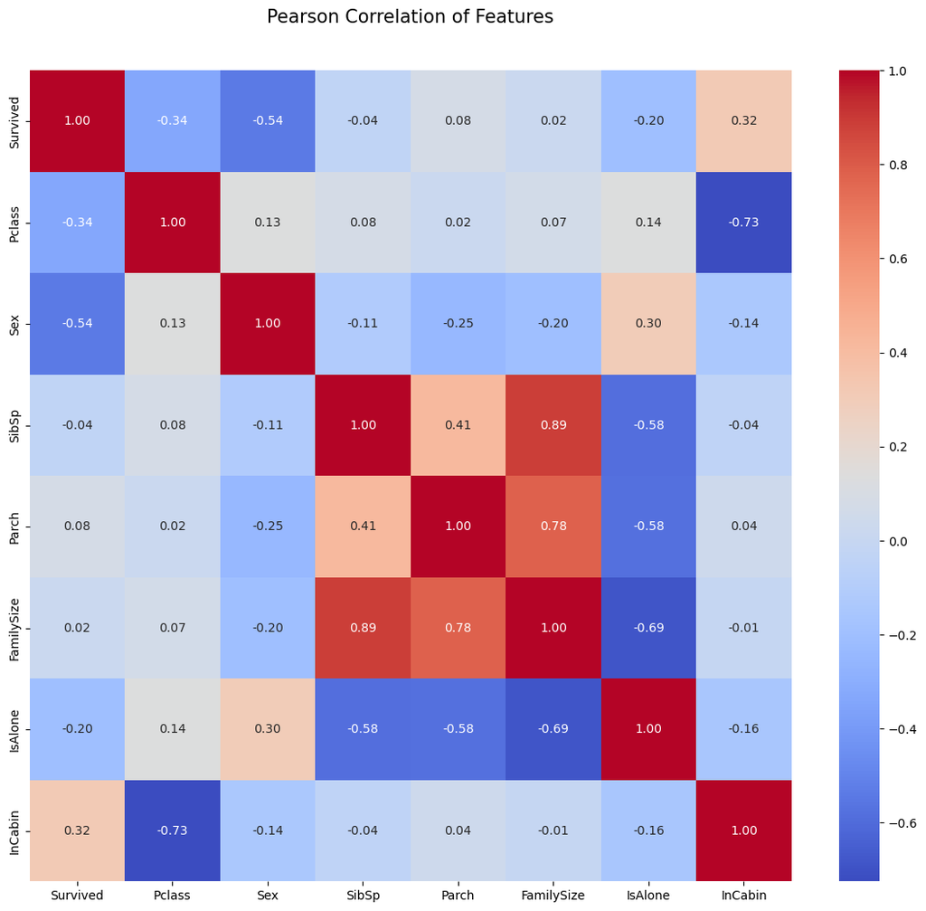

```python
correlation_matrix = df.corr(numeric_only=True)
correlation_matrix

plt.figure(figsize=(14, 12))
plt.title('Pearson Correlation of Features', y=1.05, size=15)
sns.heatmap(correlation_matrix, annot=True, cmap='coolwarm', fmt='.2f')
plt.show()
```

## Binarization of categorical variables

For each categorical variable we will make `m` binary variables, where `m` is the number of categories of the variable.

```python
cols = ['Pclass', 'Embarked', 'FareGroup', 'AgeGroup', 'Title']
titanic_categorical = df[cols]
titanic_categorical = pd.concat([pd.get_dummies(titanic_categorical[col], prefix=col) for col in titanic_categorical], axis=1)
titanic_categorical.head()
df = pd.concat([df[df.columns[~df.columns.isin(cols)]], titanic_categorical], axis=1)
df.head()
```

|  | Survived | Sex | SibSp | Parch | FamilySize | IsAlone | InCabin | Pclass_1 | Pclass_2 | Pclass_3 | ... | AgeGroup_Teenager | AgeGroup_Student | AgeGroup_Young Adult | AgeGroup_Adult | AgeGroup_Senior | Title_Master | Title_Miss | Title_Mr | Title_Mrs | Title_Rare |
| --- | --- | --- | --- | --- | --- | --- | --- | --- | --- | --- | --- | --- | --- | --- | --- | --- | --- | --- | --- | --- | --- |
| 0 | 0 | True | 1 | 0 | 2 | 0 | False | 0 | 0 | 1 | ... | 0 | 1 | 0 | 0 | 0 | 0 | 0 | 1 | 0 | 0 |
| 1 | 1 | False | 1 | 0 | 2 | 0 | True | 1 | 0 | 0 | ... | 0 | 0 | 0 | 1 | 0 | 0 | 0 | 0 | 1 | 0 |
| 2 | 1 | False | 0 | 0 | 1 | 1 | False | 0 | 0 | 1 | ... | 0 | 0 | 1 | 0 | 0 | 0 | 1 | 0 | 0 | 0 |
| 3 | 1 | False | 1 | 0 | 2 | 0 | True | 1 | 0 | 0 | ... | 0 | 0 | 1 | 0 | 0 | 0 | 0 | 0 | 1 | 0 |
| 4 | 0 | True | 0 | 0 | 1 | 1 | False | 0 | 0 | 1 | ... | 0 | 0 | 1 | 0 | 0 | 0 | 0 | 1 | 0 | 0 |

5 rows × 33 columns

## Training and test sets

We divide the data into two sets, training and test. With the training set we will create the predictive model, and with the test set, we will evaluate it to see how it performs.

```python
from sklearn.model_selection import train_test_split
X = df.drop(labels='Survived', axis=1)
y = df.Survived

X_train, X_test, y_train, y_test = train_test_split(X, y, test_size=0.30, random_state=42)
```

### Predictive Models

Now that we have the dataset prepared for analysis, we will create different prediction models and compare them. The models we will create are as follows:

- Logistic Regression
- Decision Trees
- Random Forests
- k-nearest neighbors
- Support Vector Machines We will evaluate them using the area under the ROC curve metric for each prediction model concerning the outcomes. We will then select the model that yields the best results.

```python
performance_auc = {} #Empty Dictionary
```

```python
%who
```

```
X	 X_test	 X_train	 bins	 cols	 correlation_matrix	 df	 get_title	 labels
mu	 norm	 np	 p	 pd	 performance_auc	 plt	 re	 sns
std	 titanic_categorical	 train_test_split	 x	 xmax	 xmin	 y	 y_test	 y_train
```

# Logistic regression

```python
from sklearn.linear_model import LogisticRegression

model = LogisticRegression().fit(X_train, y_train)

# Get the coefficients and intercept
coefficients = model.coef_
intercept = model.intercept_

print("Coefficients:", coefficients)
print("Intercept:", intercept)
```

```
Coefficients: [[-1.35093421e+00 -2.30998129e-01 -9.61107751e-02 -3.26199013e-01
  -3.21498085e-01  1.01739670e+00  1.44435174e-01  5.21441605e-01
  -6.64966888e-01  3.14281953e-01  1.92576772e-01 -5.05948834e-01
  -1.26718215e-01  3.62192784e-01 -5.36835619e-01 -1.29147416e-01
   6.28042101e-04  1.90343256e-02  4.11755990e-01 -3.50507359e-01
   1.12805866e+00 -2.53885004e-02 -3.74621675e-01  7.96068642e-02
   1.11450427e-01 -4.46954751e-01 -1.20733770e-01  1.43144305e+00
   4.70447016e-02 -1.34614864e+00  9.15582612e-01 -1.04701183e+00]]
Intercept: [2.12903885]
```

```python
predicted = model.predict(X_test)
predicted
```

```
array([1, 0, 0, 1, 1, 1, 1, 0, 1, 1, 0, 0, 0, 0, 0, 1, 0, 1, 0, 0, 0, 0,
       1, 0, 0, 0, 0, 0, 0, 1, 0, 1, 0, 0, 0, 0, 0, 1, 1, 0, 0, 0, 0, 0,
       1, 0, 0, 0, 0, 0, 1, 1, 0, 1, 0, 1, 0, 1, 1, 1, 0, 1, 1, 0, 0, 1,
       0, 0, 0, 1, 1, 1, 1, 1, 0, 0, 1, 1, 1, 1, 0, 1, 1, 0, 0, 0, 1, 1,
       0, 0, 0, 0, 0, 0, 0, 0, 0, 0, 1, 0, 0, 0, 1, 0, 0, 0, 1, 0, 0, 0,
       1, 0, 1, 0, 0, 0, 1, 1, 1, 0, 0, 1, 1, 1, 0, 0, 1, 1, 1, 0, 1, 1,
       0, 1, 0, 1, 1, 0, 0, 1, 0, 1, 0, 0, 0, 1, 0, 0, 1, 0, 0, 0, 0, 1,
       0, 0, 0, 1, 1, 1, 0, 0, 0, 1, 0, 1, 0, 1, 0, 0, 1, 1, 0, 1, 0, 0,
       0, 1, 1, 0, 0, 0, 0, 0, 1, 0, 0, 0, 0, 1, 0, 0, 0, 0, 1, 1, 1, 0,
       1, 0, 0, 0, 1, 1, 0, 1, 0, 0, 0, 0, 1, 0, 1, 0, 0, 0, 1, 0, 1, 0,
       0, 1, 0, 0, 0, 1, 0, 1, 1, 1, 0, 1, 0, 1, 0, 1, 1, 0, 1, 0, 0, 1,
       0, 0, 0, 0, 0, 0, 0, 0, 0, 0, 0, 0, 0, 0, 0, 1, 0, 1, 1, 0, 1, 0,
       0, 0, 0, 0], dtype=int64)
```

```
<module 'matplotlib.pyplot' from 'C:\\Users\\Panasonic\\anaconda3\\lib\\site-packages\\matplotlib\\pyplot.py'>
```

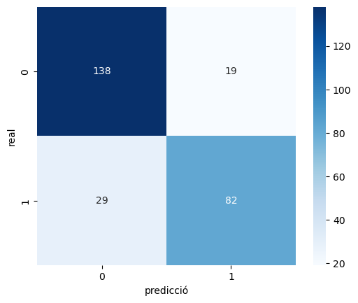

```python
import matplotlib.pyplot as plt
import seaborn as sns

from sklearn.metrics import confusion_matrix

matrix = confusion_matrix(y_test, predicted)
sns.heatmap(matrix, annot=True, fmt="d", cmap='Blues', square=True)
plt.xlabel("predicció")
plt.ylabel("real")
plt
```

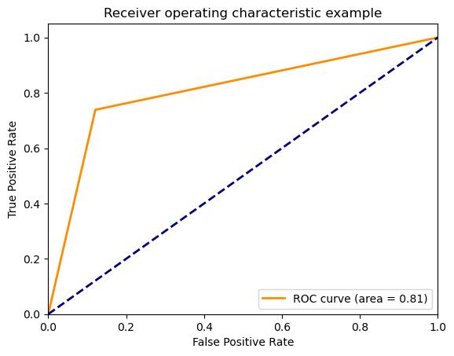

```python
from sklearn.metrics import roc_curve, auc

fpr, tpr, thresholds = roc_curve(y_test, predicted)
roc_auc = auc(fpr, tpr)
performance_auc['Logistic Regression'] = roc_auc

plt.figure()
lw = 2
plt.plot(fpr, tpr, color='darkorange', lw=lw, label='ROC curve (area = %0.2f)' % roc_auc)
plt.plot([0, 1], [0, 1], color='navy', lw=lw, linestyle='--')
plt.xlim([0.0, 1.0])
plt.ylim([0.0, 1.05])
plt.xlabel('False Positive Rate')
plt.ylabel('True Positive Rate')
plt.title('Receiver operating characteristic example')
plt.legend(loc="lower right")
plt.show()
```

### Decision trees

```python
from sklearn.tree import DecisionTreeClassifier

model = DecisionTreeClassifier().fit(X_train, y_train)

# Get feature importances
feature_importances = model.feature_importances_

# Get the number of nodes in the tree
num_nodes = model.tree_.node_count

# Print the feature importances and number of nodes
print("Feature Importances:", feature_importances)
print("Number of Nodes in the Tree:", num_nodes)
```

```
Feature Importances: [0.00000000e+00 1.65102621e-02 1.42790931e-02 1.05916813e-01
 6.02407922e-03 4.44315676e-02 1.43650387e-02 5.96850732e-03
 1.16344312e-01 1.41462060e-02 1.84415059e-02 1.34725036e-02
 2.54672481e-02 8.97146481e-03 1.49435277e-02 6.71661556e-03
 9.37467780e-03 9.97837229e-03 1.00094869e-02 2.51572864e-02
 2.15985571e-02 0.00000000e+00 2.66646417e-04 7.73671585e-03
 2.95822489e-02 2.89778266e-02 9.57777049e-03 0.00000000e+00
 1.37694543e-02 3.63960512e-01 0.00000000e+00 4.40117003e-02]
Number of Nodes in the Tree: 255
```

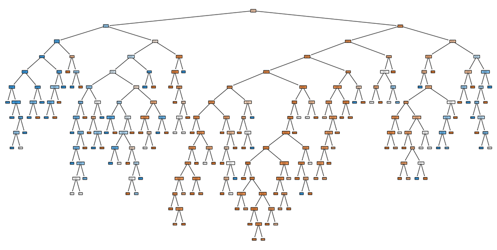

```python
from sklearn.tree import plot_tree

# Visualizing the decision tree
plt.figure(figsize=(20, 10))
plot_tree(model, filled=True, feature_names=X_train.columns, class_names=['0', '1'])
plt.show()
```

```
<module 'matplotlib.pyplot' from 'C:\\Users\\Panasonic\\anaconda3\\lib\\site-packages\\matplotlib\\pyplot.py'>
```

[figure not shown]

```python
import matplotlib.pyplot as plt
import seaborn as sns

from sklearn.metrics import confusion_matrix

matrix = confusion_matrix(y_test, predicted)
sns.heatmap(matrix, annot=True, fmt="d", cmap='Blues', square=True)
plt.xlabel("predicción")
plt.ylabel("real")
plt
```

[figure not shown]

```python
from sklearn.metrics import roc_curve, auc

fpr, tpr, thresholds = roc_curve(y_test, predicted)
roc_auc = auc(fpr, tpr)
performance_auc['Decision Tree'] = roc_auc

plt.figure()
lw = 2
plt.plot(fpr, tpr, color='darkorange', lw=lw, label='ROC curve (area = %0.2f)' % roc_auc)
plt.plot([0, 1], [0, 1], color='navy', lw=lw, linestyle='--')
plt.xlim([0.0, 1.0])
plt.ylim([0.0, 1.05])
plt.xlabel('False Positive Rate')
plt.ylabel('True Positive Rate')
plt.title('Receiver operating characteristic example')
plt.legend(loc="lower right")
plt.show()
```

```python
pd.concat((pd.DataFrame(X_train.iloc[:, 1:].columns, columns = ['variable']),
           pd.DataFrame(model.feature_importances_, columns = ['importance'])),
          axis = 1).sort_values(by='importance', ascending = False)[:20]
```

|  | variable | importance |
| --- | --- | --- |
| 29 | Title_Mrs | 0.363961 |
| 8 | Embarked_C | 0.116344 |
| 3 | IsAlone | 0.105917 |
| 5 | Pclass_1 | 0.044432 |
| 31 | NaN | 0.044012 |
| 24 | AgeGroup_Adult | 0.029582 |
| 25 | AgeGroup_Senior | 0.028978 |
| 12 | FareGroup_B | 0.025467 |
| 19 | AgeGroup_Baby | 0.025157 |
| 20 | AgeGroup_Child | 0.021599 |
| 10 | Embarked_S | 0.018442 |
| 1 | Parch | 0.016510 |
| 14 | FareGroup_D | 0.014944 |
| 6 | Pclass_2 | 0.014365 |
| 2 | FamilySize | 0.014279 |
| 9 | Embarked_Q | 0.014146 |
| 28 | Title_Mr | 0.013769 |
| 11 | FareGroup_A | 0.013473 |
| 18 | AgeGroup_Unknown | 0.010009 |
| 17 | FareGroup_G | 0.009978 |

## Random Forest

```python
from sklearn.ensemble import RandomForestClassifier


model = RandomForestClassifier(n_estimators=1000).fit(X_train, y_train)

# Get the feature importances
feature_importances = model.feature_importances_

# Predict on new data (X_test)
y_pred = model.predict(X_test)

# Evaluate the model's performance
accuracy = model.score(X_test, y_test)  # Accuracy on the test set
# We can use other evaluation metrics, e.g., confusion matrix, ROC AUC, etc.

# Print the feature importances and accuracy
print("Feature Importances:", feature_importances)
print("Model Accuracy:", accuracy)
```

```
Feature Importances: [0.12797438 0.04080987 0.02958903 0.05981278 0.01510198 0.04983048
 0.02114992 0.02429846 0.05575202 0.02335158 0.01358702 0.02415359
 0.02226135 0.01879795 0.01681573 0.01768928 0.01482299 0.02648228
 0.01849042 0.02464705 0.02285737 0.00539538 0.01324031 0.01757225
 0.02831117 0.02300574 0.00755807 0.01204701 0.04093541 0.12958053
 0.04491414 0.00916446]
Model Accuracy: 0.8097014925373134
```

```python
predicted = model.predict(X_test)
predicted
```

```
array([1, 0, 0, 1, 0, 1, 1, 0, 1, 1, 0, 0, 0, 0, 0, 1, 0, 1, 0, 0, 0, 0,
       0, 0, 0, 0, 0, 0, 0, 1, 0, 1, 0, 1, 0, 0, 0, 1, 1, 0, 0, 0, 0, 0,
       1, 0, 0, 0, 0, 1, 1, 1, 0, 1, 0, 1, 0, 1, 1, 1, 0, 1, 1, 0, 0, 1,
       0, 0, 0, 1, 1, 1, 0, 1, 0, 0, 1, 1, 1, 1, 0, 1, 1, 0, 0, 0, 1, 1,
       0, 0, 1, 0, 0, 0, 0, 0, 0, 0, 1, 0, 0, 0, 1, 0, 0, 1, 1, 0, 0, 0,
       1, 0, 1, 1, 0, 0, 0, 0, 1, 0, 0, 1, 1, 1, 0, 0, 1, 0, 1, 0, 1, 1,
       0, 0, 1, 1, 1, 0, 0, 1, 0, 1, 0, 0, 0, 1, 0, 0, 1, 0, 0, 0, 0, 1,
       0, 0, 0, 1, 1, 1, 0, 0, 0, 1, 0, 1, 0, 1, 0, 0, 1, 1, 1, 0, 0, 0,
       0, 1, 1, 0, 0, 0, 1, 0, 1, 1, 0, 0, 0, 1, 0, 0, 0, 0, 1, 1, 1, 0,
       1, 0, 0, 0, 1, 1, 0, 0, 0, 0, 0, 0, 1, 0, 1, 0, 0, 0, 1, 0, 1, 0,
       0, 1, 0, 0, 0, 1, 0, 1, 1, 1, 0, 1, 0, 1, 0, 0, 1, 0, 1, 0, 0, 1,
       0, 0, 0, 0, 0, 0, 0, 0, 0, 0, 0, 0, 0, 0, 0, 1, 0, 1, 1, 1, 1, 0,
       0, 0, 0, 1], dtype=int64)
```

```
<module 'matplotlib.pyplot' from 'C:\\Users\\Panasonic\\anaconda3\\lib\\site-packages\\matplotlib\\pyplot.py'>
```

[figure not shown]

```python
import matplotlib.pyplot as plt
import seaborn as sns

from sklearn.metrics import confusion_matrix

matrix = confusion_matrix(y_test, predicted)
sns.heatmap(matrix, annot=True, fmt="d", cmap='Blues', square=True)
plt.xlabel("predicción")
plt.ylabel("real")
plt
```

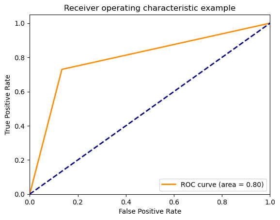

```python
from sklearn.metrics import roc_curve, auc

fpr, tpr, thresholds = roc_curve(y_test, predicted)
roc_auc = auc(fpr, tpr)
performance_auc['Random Forests'] = roc_auc

plt.figure()
lw = 2
plt.plot(fpr, tpr, color='darkorange', lw=lw, label='ROC curve (area = %0.2f)' % roc_auc)
plt.plot([0, 1], [0, 1], color='navy', lw=lw, linestyle='--')
plt.xlim([0.0, 1.0])
plt.ylim([0.0, 1.05])
plt.xlabel('False Positive Rate')
plt.ylabel('True Positive Rate')
plt.title('Receiver operating characteristic example')
plt.legend(loc="lower right")
plt.show()
```

```python
pd.concat((pd.DataFrame(X_train.iloc[:, 1:].columns, columns = ['variable']),
           pd.DataFrame(model.feature_importances_, columns = ['importance'])),
          axis = 1).sort_values(by='importance', ascending = False)[:20]
```

|  | variable | importance |
| --- | --- | --- |
| 29 | Title_Mrs | 0.130578 |
| 0 | SibSp | 0.128849 |
| 3 | IsAlone | 0.061739 |
| 8 | Embarked_C | 0.053645 |
| 5 | Pclass_1 | 0.049275 |
| 30 | Title_Rare | 0.043787 |
| 28 | Title_Mr | 0.041868 |
| 1 | Parch | 0.038882 |
| 2 | FamilySize | 0.029711 |
| 24 | AgeGroup_Adult | 0.028501 |
| 17 | FareGroup_G | 0.025635 |
| 7 | Pclass_3 | 0.025290 |
| 11 | FareGroup_A | 0.024434 |
| 19 | AgeGroup_Baby | 0.024359 |
| 6 | Pclass_2 | 0.024000 |
| 9 | Embarked_Q | 0.023262 |
| 25 | AgeGroup_Senior | 0.022734 |
| 20 | AgeGroup_Child | 0.022654 |
| 12 | FareGroup_B | 0.021511 |
| 13 | FareGroup_C | 0.018444 |

### k-nearest neighbors

```python
from sklearn.neighbors import KNeighborsClassifier

model = KNeighborsClassifier(n_neighbors=3).fit(X_train, y_train)

# Predict on new data (X_test)
y_pred = model.predict(X_test)

# Evaluate the model's performance
accuracy = model.score(X_test, y_test)  # Accuracy on the test set


# Print the model's accuracy
print("Model Accuracy:", accuracy)
# Displaying a detailed representation of the model
print(model)
# or 'print(repr(model))'
```

```
Model Accuracy: 0.8059701492537313
KNeighborsClassifier(n_neighbors=3)
```

```python
predicted = model.predict(X_test)
predicted
```

```
array([1, 0, 0, 1, 0, 1, 1, 0, 0, 1, 0, 0, 0, 0, 0, 1, 0, 1, 0, 0, 0, 0,
       0, 0, 0, 0, 0, 0, 0, 0, 0, 1, 0, 1, 0, 0, 0, 1, 1, 0, 0, 0, 0, 0,
       0, 0, 0, 0, 0, 1, 1, 1, 0, 0, 0, 1, 0, 1, 1, 0, 0, 1, 1, 0, 0, 1,
       0, 0, 0, 1, 1, 1, 0, 1, 0, 0, 0, 1, 1, 1, 0, 1, 1, 0, 0, 0, 1, 1,
       0, 0, 1, 0, 0, 0, 0, 0, 0, 0, 1, 0, 0, 0, 1, 0, 0, 1, 1, 0, 0, 0,
       1, 0, 1, 1, 0, 0, 0, 0, 1, 0, 0, 1, 1, 1, 0, 0, 1, 0, 1, 0, 1, 1,
       0, 0, 1, 0, 1, 0, 0, 0, 0, 1, 0, 0, 0, 1, 0, 0, 1, 0, 0, 0, 0, 1,
       0, 0, 1, 1, 1, 0, 0, 0, 0, 1, 0, 1, 0, 1, 0, 0, 0, 1, 1, 1, 0, 0,
       0, 1, 1, 0, 0, 0, 1, 0, 0, 0, 0, 0, 0, 1, 0, 0, 0, 0, 1, 1, 1, 0,
       1, 0, 0, 0, 1, 0, 0, 1, 0, 1, 0, 0, 1, 0, 1, 0, 0, 0, 1, 1, 1, 0,
       0, 1, 0, 0, 0, 1, 0, 1, 1, 0, 0, 1, 0, 0, 0, 0, 1, 0, 1, 0, 0, 1,
       0, 0, 0, 0, 0, 0, 0, 0, 0, 0, 0, 0, 0, 0, 0, 1, 0, 1, 1, 1, 1, 0,
       0, 0, 0, 0], dtype=int64)
```

```
<module 'matplotlib.pyplot' from 'C:\\Users\\Panasonic\\anaconda3\\lib\\site-packages\\matplotlib\\pyplot.py'>
```

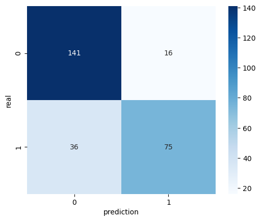

```python
import matplotlib.pyplot as plt
import seaborn as sns

from sklearn.metrics import confusion_matrix

matrix = confusion_matrix(y_test, predicted)
sns.heatmap(matrix, annot=True, fmt="d", cmap='Blues', square=True)
plt.xlabel("prediction")
plt.ylabel("real")
plt
```

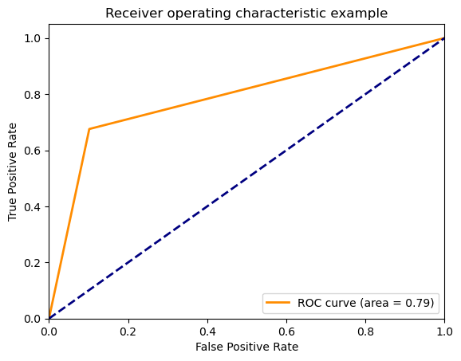

```python
from sklearn.metrics import roc_curve, auc

fpr, tpr, thresholds = roc_curve(y_test, predicted)
roc_auc = auc(fpr, tpr)
performance_auc['k-nearest neighbours'] = roc_auc

plt.figure()
lw = 2
plt.plot(fpr, tpr, color='darkorange', lw=lw, label='ROC curve (area = %0.2f)' % roc_auc)
plt.plot([0, 1], [0, 1], color='navy', lw=lw, linestyle='--')
plt.xlim([0.0, 1.0])
plt.ylim([0.0, 1.05])
plt.xlabel('False Positive Rate')
plt.ylabel('True Positive Rate')
plt.title('Receiver operating characteristic example')
plt.legend(loc="lower right")
plt.show()
```

### Support Vector Machines

```python
from sklearn.svm import SVC


model = SVC(probability=True).fit(X_train, y_train)

# Get the support vectors
support_vectors = model.support_vectors_

# Get the support indices
support_indices = model.support_

# Get the number of support vectors for each class
n_support_vectors = model.n_support_

# Predict on new data (X_test)
y_pred = model.predict(X_test)

# Evaluate the model's performance
accuracy = model.score(X_test, y_test)  # Accuracy on the test set

# Print the number of support vectors and accuracy
print("Number of Support Vectors:", n_support_vectors)
print("Model Accuracy:", accuracy)
```

```
Number of Support Vectors: [168 153]
Model Accuracy: 0.835820895522388
```

```python
predicted = model.predict(X_test)
predicted
```

```
array([1, 0, 0, 1, 1, 1, 1, 0, 1, 1, 0, 0, 0, 0, 0, 1, 0, 1, 0, 0, 0, 0,
       1, 0, 0, 0, 0, 0, 0, 1, 0, 1, 0, 1, 0, 0, 0, 1, 1, 0, 0, 0, 0, 0,
       1, 0, 0, 0, 0, 0, 1, 1, 0, 1, 0, 1, 0, 1, 1, 1, 0, 1, 1, 0, 0, 1,
       0, 0, 0, 1, 1, 1, 0, 1, 0, 0, 1, 1, 1, 1, 0, 1, 1, 0, 0, 0, 1, 1,
       0, 0, 1, 0, 0, 0, 0, 0, 0, 0, 1, 0, 0, 0, 1, 0, 0, 0, 1, 0, 0, 0,
       1, 0, 1, 0, 0, 0, 0, 0, 1, 0, 0, 1, 1, 1, 0, 0, 1, 0, 1, 0, 1, 1,
       0, 1, 0, 1, 1, 0, 0, 1, 0, 1, 0, 0, 0, 1, 0, 0, 1, 0, 0, 0, 0, 1,
       0, 0, 0, 1, 1, 1, 0, 0, 0, 1, 0, 0, 0, 1, 0, 0, 0, 1, 0, 1, 0, 0,
       0, 1, 1, 0, 0, 0, 0, 0, 0, 0, 0, 0, 0, 1, 0, 0, 0, 0, 1, 1, 1, 0,
       1, 0, 0, 1, 1, 1, 0, 1, 0, 0, 0, 0, 0, 0, 1, 0, 0, 0, 1, 0, 1, 0,
       0, 1, 0, 0, 0, 1, 0, 1, 1, 1, 0, 1, 0, 1, 0, 1, 1, 1, 1, 0, 0, 1,
       0, 1, 0, 0, 0, 0, 0, 0, 1, 0, 0, 0, 0, 0, 0, 1, 0, 1, 1, 0, 1, 0,
       0, 0, 0, 0], dtype=int64)
```

```
<module 'matplotlib.pyplot' from 'C:\\Users\\Panasonic\\anaconda3\\lib\\site-packages\\matplotlib\\pyplot.py'>
```

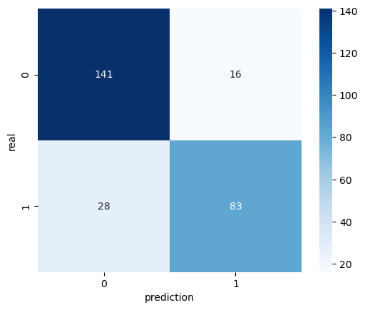

```python
import matplotlib.pyplot as plt
import seaborn as sns

from sklearn.metrics import confusion_matrix

matrix = confusion_matrix(y_test, predicted)
sns.heatmap(matrix, annot=True, fmt="d", cmap='Blues', square=True)
plt.xlabel("prediction")
plt.ylabel("real")
plt
```

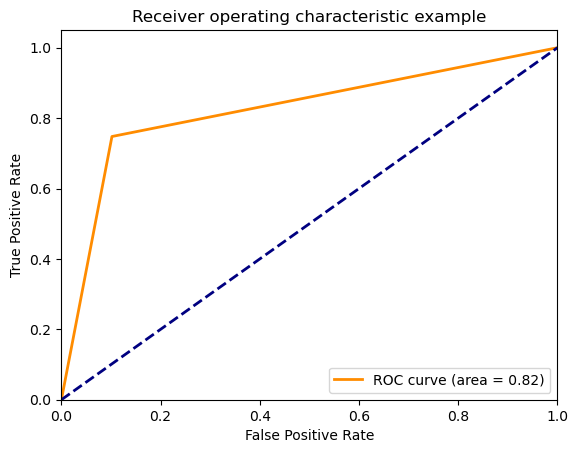

```python
from sklearn.metrics import roc_curve, auc

fpr, tpr, thresholds = roc_curve(y_test, predicted)
roc_auc = auc(fpr, tpr)
performance_auc['SVM'] = roc_auc

plt.figure()
lw = 2
plt.plot(fpr, tpr, color='darkorange', lw=lw, label='ROC curve (area = %0.2f)' % roc_auc)
plt.plot([0, 1], [0, 1], color='navy', lw=lw, linestyle='--')
plt.xlim([0.0, 1.0])
plt.ylim([0.0, 1.05])
plt.xlabel('False Positive Rate')
plt.ylabel('True Positive Rate')
plt.title('Receiver operating characteristic example')
plt.legend(loc="lower right")
plt.show()
```

## Conclusion

After applying different classification models, and seeing that there are not too many differences in performance between them, the one that has given us the best result with the metric we have chosen has been the Support Vector Machines model.

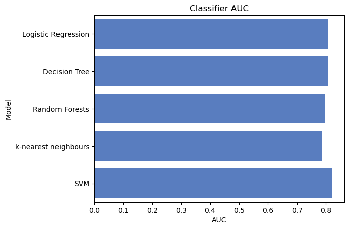

```python
perf = pd.DataFrame.from_dict(performance_auc, orient='index')
perf['Model'] = perf.index
perf['AUC'] = perf[0]
plt.xlabel('AUC')
plt.title('Classifier AUC')
sns.set_color_codes("muted")
sns.barplot(x='AUC', y='Model', data=perf, color="b")
```

```python
print(performance_auc)
```

```
{'Logistic Regression': 0.808859815229242, 'Decision Tree': 0.808859815229242, 'Random Forests': 0.7979858839731452, 'k-nearest neighbours': 0.786882423825099, 'SVM': 0.8229184598611351}
```

[figure not shown]

# Clasification models evaluation

## Who survived the Titanic?

August 2022

Mit Licence Copyright (c) 2023 Antonio Barrera Mora